# Relatório 05

Gustavo Cardoso

12/05/2025

# 1 Objetivo

Este experimento teve como objetivo avaliar a resistência à compressão (MPa) de três tipos de cimento (A, B e C) sob diferentes condições de cura, representadas por quatro câmaras de cura com variações de temperatura. Utilizou-se um Delineamento em Blocos Casualizados (DBC), onde os blocos representam as câmaras e os tratamentos os tipos de cimento.

# 2 Apresentação do relatório

Neste relatório, apresentamos a análise estatística do experimento descrito, com foco na comparação dos tratamentos (tipos de cimento) em diferentes blocos (condições de cura). Foram aplicadas técnicas de análise descritiva, análise de variância (ANOVA) e verificação dos pressupostos do modelo. O estudo foi conduzido no software R, com auxílio de gráficos e testes estatísticos.

# 3 Análise Descritiva

| Media | Desvio_Padrão | CV |
| --- | --- | --- |
| 32.4 | 1.934848 | 5.971753 |

| Cimento | Média | Desvio | CV |
| --- | --- | --- | --- |
| A | 32.200 | 0.7615773 | 2.365147 |
| B | 34.675 | 0.5377422 | 1.550807 |
| C | 30.325 | 0.4031129 | 1.329309 |

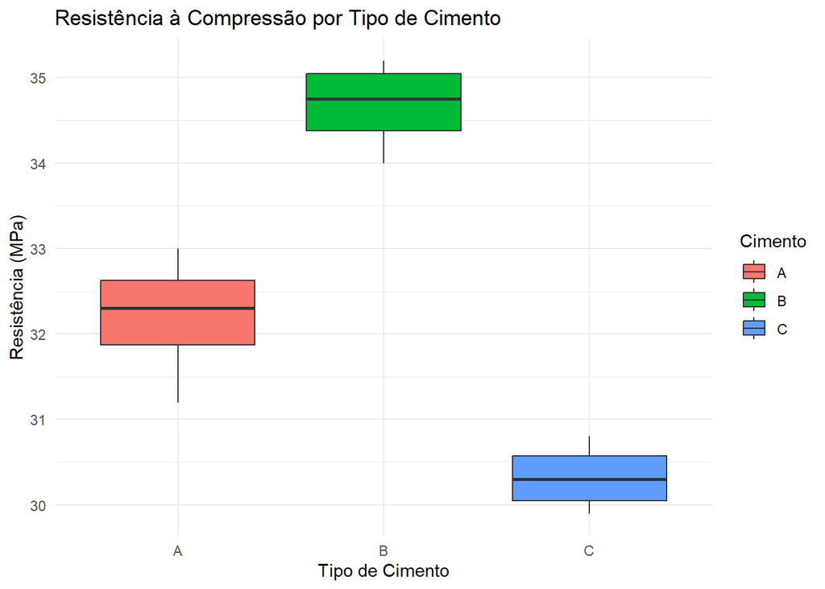

# 4 Análise de Variância (ANOVA)

Hipóteses:

H0 : Não há diferença entre as médias de resistência dos cimentos.

H1 : Pelo menos um cimento tem média de resistência diferente.

```
##             Df Sum Sq Mean Sq F value  Pr(>F)
## Cimento      2  38.08  19.042  46.666 0.00022 ***
## Bloco        3   0.65   0.216   0.528 0.67911
## Residuals    6   2.45   0.408
## ---
## Signif. codes:  0 '***' 0.001 '**' 0.01 '*' 0.05 '.' 0.1 ' ' 1
```

# 5 Teste dos Pressupostos

Normalidade dos resíduos:

```
##
##  Shapiro-Wilk normality test
##
## data:  residuals(modelo_dbc)
## W = 0.97112, p-value = 0.9221
```

Homogeneidade das variâncias:

```
## Levene's Test for Homogeneity of Variance (center = median)
##       Df F value Pr(>F)
## group  2  0.5683 0.5856
##        9
```

# 6 Análise gráfica dos resíduos

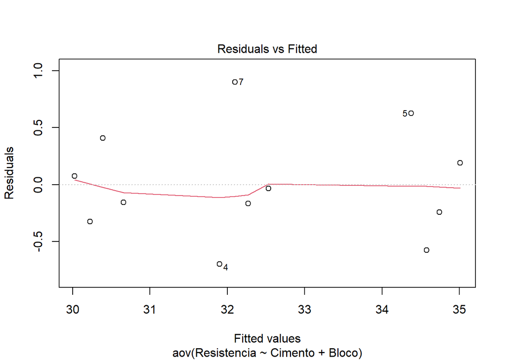

# 7 Conclusão

A análise de variância indicou se houve ou não efeito significativo do tipo de cimento sobre a resistência à compressão dos blocos, considerando o controle dos efeitos de variação entre os blocos (câmaras). A verificação dos pressupostos estatísticos confirmou a adequação do modelo ANOVA. Dessa forma, é possível inferir com segurança sobre o desempenho comparativo entre os cimentos testados.